# bikersharing-demand

Zhaohui Zhu

2019/12/1

Bike sharing systems are a means of renting bicycles where the process of obtaining membership, rental, and bike return is automated via a network of kiosk locations throughout a city. Using these systems, people are able rent a bike from a one location and return it to a different place on an as-needed basis. Currently, there are over 500 bike-sharing programs around the world.

The data generated by these systems makes them attractive for researchers because the duration of travel, departure location, arrival location, and time elapsed is explicitly recorded. Bike sharing systems therefore function as a sensor network, which can be used for studying mobility in a city

```r
library(tidyverse)
library(magrittr)
library(readxl)
library(DT)


data_bikeshare <- read_csv("data.csv")
data_bikeshare %>% glimpse()
```

```
## Observations: 10,886
## Variables: 12
## $ datetime   <dttm> 2011-01-01 00:00:00, 2011-01-01 01:00:00, 2011-01-01 02...
## $ season     <dbl> 1, 1, 1, 1, 1, 1, 1, 1, 1, 1, 1, 1, 1, 1, 1, 1, 1, 1, 1,...
## $ holiday    <dbl> 0, 0, 0, 0, 0, 0, 0, 0, 0, 0, 0, 0, 0, 0, 0, 0, 0, 0, 0,...
## $ workingday <dbl> 0, 0, 0, 0, 0, 0, 0, 0, 0, 0, 0, 0, 0, 0, 0, 0, 0, 0, 0,...
## $ weather    <dbl> 1, 1, 1, 1, 1, 2, 1, 1, 1, 1, 1, 1, 1, 2, 2, 2, 2, 2, 3,...
## $ temp       <dbl> 9.84, 9.02, 9.02, 9.84, 9.84, 9.84, 9.02, 8.20, 9.84, 13...
## $ atemp      <dbl> 14.395, 13.635, 13.635, 14.395, 14.395, 12.880, 13.635, ...
## $ humidity   <dbl> 81, 80, 80, 75, 75, 75, 80, 86, 75, 76, 76, 81, 77, 72, ...
## $ windspeed  <dbl> 0.0000, 0.0000, 0.0000, 0.0000, 0.0000, 6.0032, 0.0000, ...
## $ casual     <dbl> 3, 8, 5, 3, 0, 0, 2, 1, 1, 8, 12, 26, 29, 47, 35, 40, 41...
## $ registered <dbl> 13, 32, 27, 10, 1, 1, 0, 2, 7, 6, 24, 30, 55, 47, 71, 70...
## $ count      <dbl> 16, 40, 32, 13, 1, 1, 2, 3, 8, 14, 36, 56, 84, 94, 106, ...
```

```r
data_bikeshare %>% head()
```

```
## # A tibble: 6 x 12
##   datetime            season holiday workingday weather  temp atemp humidity
##   <dttm>               <dbl>   <dbl>      <dbl>   <dbl> <dbl> <dbl>    <dbl>
## 1 2011-01-01 00:00:00      1       0          0       1  9.84  14.4       81
## 2 2011-01-01 01:00:00      1       0          0       1  9.02  13.6       80
## 3 2011-01-01 02:00:00      1       0          0       1  9.02  13.6       80
## 4 2011-01-01 03:00:00      1       0          0       1  9.84  14.4       75
## 5 2011-01-01 04:00:00      1       0          0       1  9.84  14.4       75
## 6 2011-01-01 05:00:00      1       0          0       2  9.84  12.9       75
## # ... with 4 more variables: windspeed <dbl>, casual <dbl>, registered <dbl>,
## #   count <dbl>
```

```r
data_bikeshare %>% str()
```

```
## Classes 'spec_tbl_df', 'tbl_df', 'tbl' and 'data.frame': 10886 obs. of  12 variables:
##  $ datetime  : POSIXct, format: "2011-01-01 00:00:00" "2011-01-01 01:00:00" ...
##  $ season    : num  1 1 1 1 1 1 1 1 1 1 ...
##  $ holiday   : num  0 0 0 0 0 0 0 0 0 0 ...
##  $ workingday: num  0 0 0 0 0 0 0 0 0 0 ...
##  $ weather   : num  1 1 1 1 1 2 1 1 1 1 ...
##  $ temp      : num  9.84 9.02 9.02 9.84 9.84 ...
##  $ atemp     : num  14.4 13.6 13.6 14.4 14.4 ...
##  $ humidity  : num  81 80 80 75 75 75 80 86 75 76 ...
##  $ windspeed : num  0 0 0 0 0 ...
##  $ casual    : num  3 8 5 3 0 0 2 1 1 8 ...
##  $ registered: num  13 32 27 10 1 1 0 2 7 6 ...
##  $ count     : num  16 40 32 13 1 1 2 3 8 14 ...
##  - attr(*, "spec")=
##   .. cols(
##   ..   datetime = col_datetime(format = ""),
##   ..   season = col_double(),
##   ..   holiday = col_double(),
##   ..   workingday = col_double(),
##   ..   weather = col_double(),
##   ..   temp = col_double(),
##   ..   atemp = col_double(),
##   ..   humidity = col_double(),
##   ..   windspeed = col_double(),
##   ..   casual = col_double(),
##   ..   registered = col_double(),
##   ..   count = col_double()
##   .. )
```

This dataset contains 12 Variables.

- datetime - hourly date + timestamp
- season - 1 = spring, 2 = summer, 3 = fall, 4 = winter
- holiday - whether the day is considered a holiday
- workingday - whether the day is neither a weekend nor holiday
- weather
- 1: Clear, Few clouds, Partly cloudy, Partly cloudy
- 2: Mist + Cloudy, Mist + Broken clouds, Mist + Few clouds, Mist
- 3: Light Snow, Light Rain + Thunderstorm + Scattered clouds, Light Rain + Scattered clouds
- 4: Heavy Rain + Ice Pallets + Thunderstorm + Mist, Snow + Fog
- temp - temperature in Celsius
- atemp - ‘Feels like’ temperature in Celsius
- humidity - relative humidity
- windspeed - wind speed
- casual - number of non-registered user rentals initiated
- registered - number of registered user rentals initiated
- count - number of total rentals

### Exploratory analysis

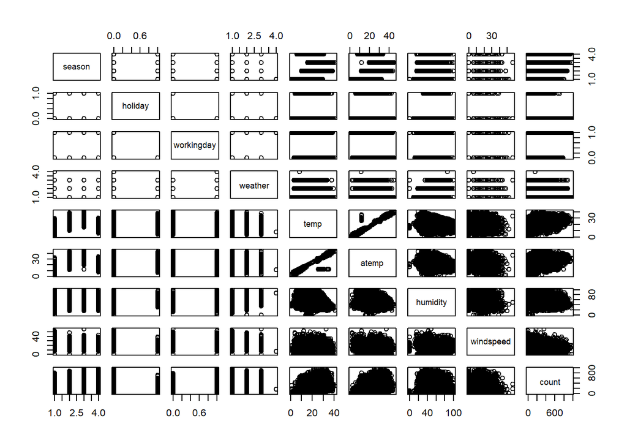

```r
data_bikeshare %>%
  dplyr::select(-c(casual,registered,datetime)) %>%
  pairs()
```

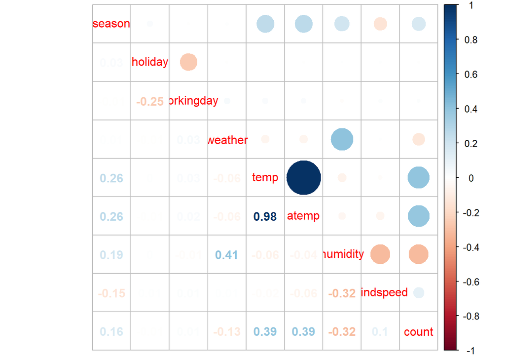

```r
library(corrplot)
# data_cor <- cor(data_bikeshare[,c('temp','count')])

data_cor <- cor(data_bikeshare[,-c(1,10,11)])

corrplot::corrplot.mixed(data_cor)
```

It can be seen from the figure that season, weather, temp, atemp and humidity are related to count Other variables are not strongly correlated with count.

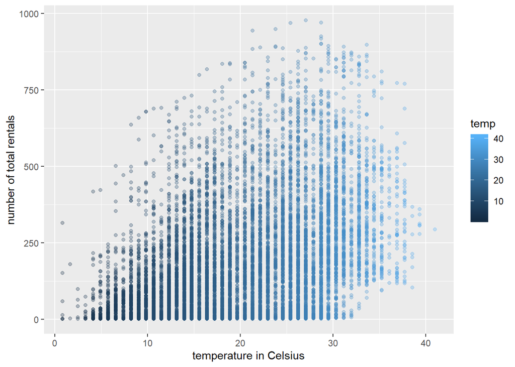

```r
ggplot(data = data_bikeshare, aes(temp,count)) +
  geom_point(alpha = 0.3, aes(color = temp)) +
  xlab("temperature in Celsius") +
  ylab("number of total rentals")
```

The scatter plot above shows that as the temperature rises, the amount of total rent also increases.

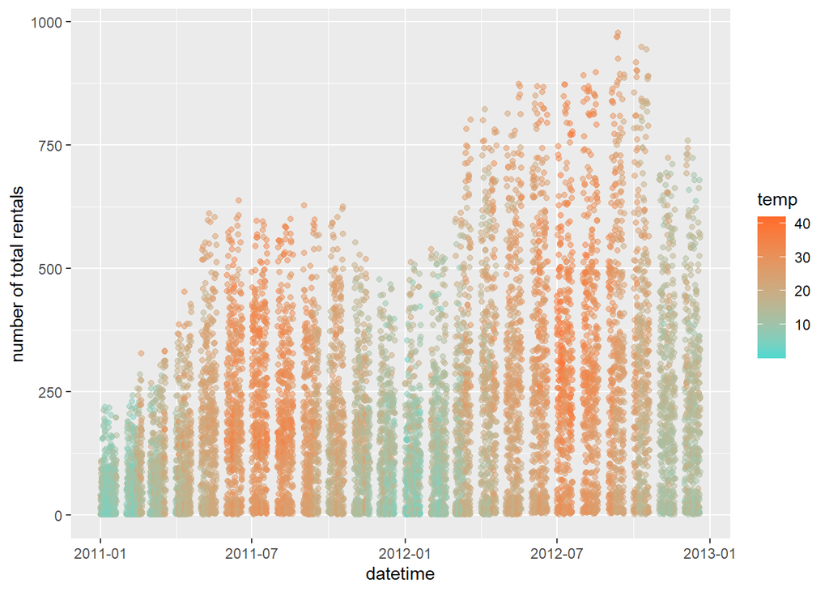

```r
pl <- ggplot(data_bikeshare,
             aes(datetime,count)) +
  geom_point(aes(color=temp),alpha=0.5)
pl + scale_color_continuous(low = '#55D8CE',high = '#FF6E2E') +
  ylab("number of total rentals")
```

### Data cleaning

```r
data_bikeshare$season <- as.factor(data_bikeshare$season)

data_bikeshare$holiday <- as.factor(data_bikeshare$holiday)

data_bikeshare$workingday <- as.factor(data_bikeshare$workingday)

data_bikeshare$weather <- as.factor(data_bikeshare$weather)

str(data_bikeshare)
```

```
## Classes 'spec_tbl_df', 'tbl_df', 'tbl' and 'data.frame': 10886 obs. of  12 variables:
##  $ datetime  : POSIXct, format: "2011-01-01 00:00:00" "2011-01-01 01:00:00" ...
##  $ season    : Factor w/ 4 levels "1","2","3","4": 1 1 1 1 1 1 1 1 1 1 ...
##  $ holiday   : Factor w/ 2 levels "0","1": 1 1 1 1 1 1 1 1 1 1 ...
##  $ workingday: Factor w/ 2 levels "0","1": 1 1 1 1 1 1 1 1 1 1 ...
##  $ weather   : Factor w/ 4 levels "1","2","3","4": 1 1 1 1 1 2 1 1 1 1 ...
##  $ temp      : num  9.84 9.02 9.02 9.84 9.84 ...
##  $ atemp     : num  14.4 13.6 13.6 14.4 14.4 ...
##  $ humidity  : num  81 80 80 75 75 75 80 86 75 76 ...
##  $ windspeed : num  0 0 0 0 0 ...
##  $ casual    : num  3 8 5 3 0 0 2 1 1 8 ...
##  $ registered: num  13 32 27 10 1 1 0 2 7 6 ...
##  $ count     : num  16 40 32 13 1 1 2 3 8 14 ...
##  - attr(*, "spec")=
##   .. cols(
##   ..   datetime = col_datetime(format = ""),
##   ..   season = col_double(),
##   ..   holiday = col_double(),
##   ..   workingday = col_double(),
##   ..   weather = col_double(),
##   ..   temp = col_double(),
##   ..   atemp = col_double(),
##   ..   humidity = col_double(),
##   ..   windspeed = col_double(),
##   ..   casual = col_double(),
##   ..   registered = col_double(),
##   ..   count = col_double()
##   .. )
```

### Variable Selection

I choose lasso for variable selection

```r
library(glmnet)
library(ISLR)



data_bikeshare_mat <- data_bikeshare %>%
  dplyr::select(-c(casual,registered,datetime))

dim(data_bikeshare_mat)
```

```
## [1] 10886     9
```

```r
data_bikeshare_mat_x <- model.matrix(count~.,data = data_bikeshare_mat)[,-1]
dim(data_bikeshare_mat_x)
```

```
## [1] 10886    12
```

The first lasso package, the results are not very good.

```r
data_bikeshare_mat_y <- data_bikeshare$count  # 因变???

lasso_mod <- cv.glmnet(x = data_bikeshare_mat_x,
                       y = data_bikeshare_mat_y,
                       alpha = 1,
                       family="gaussian",
                       type.measure="mae")

bestlam <- lasso_mod$lambda.min

grid <- 10^seq(10,-2,length.out = 100)

fit <- glmnet(data_bikeshare_mat_x,
              data_bikeshare_mat_y,
              alpha = 1,
              family="gaussian",
              lambda = grid)

lasso_coef <- predict(fit,type = "coefficients",s = bestlam)[1:13,]

lasso_coef[lasso_coef!=0]
```

```
## (Intercept)     season2     season3     season4    holiday1 workingday1
## 122.1166587  -0.7230148 -34.5898084  65.6770738  -8.3264779  -2.2711991
##    weather2    weather3    weather4        temp       atemp    humidity
##  13.7874360  -8.7395843 171.9878614   7.8884446   2.8606869  -2.8130587
##   windspeed
##   0.5881137
```

The second lasso package-hdm, this was developed by a professor at Stanford University, and the speed and quality are better than the previous one.

```r
hdm::rlasso(x = as.matrix(data_bikeshare_mat_x), y = data_bikeshare_mat_y)
```

```
##
## Call:
## rlasso.default(x = as.matrix(data_bikeshare_mat_x), y = data_bikeshare_mat_y)
##
## Coefficients:
## (Intercept)      season2      season3      season4     holiday1  workingday1
##    122.5171       0.0000     -34.3414      66.4096       0.0000       0.0000
##    weather2     weather3     weather4         temp        atemp     humidity
##     15.4419       0.0000       0.0000       7.8384       2.9147      -2.8700
##   windspeed
##      0.5521
```

Therefore the selected variables are: season3 season4 weather2 temp atemp humidity windspeed.

### Build the model

```r
data_bikeshare_mat_x %<>% as_tibble %>% dplyr::select(season3,
                                                      season4,
                                                      weather2,
                                                      temp,
                                                      atemp,
                                                      humidity,
                                                      windspeed)

data_bikeshare_lm <- cbind(data_bikeshare_mat_x,count = data_bikeshare_mat_y) %>% as.data.frame()


lm.fit <- lm(count~.-atemp,data = data_bikeshare_lm)

summary(lm.fit)
```

```
##
## Call:
## lm(formula = count ~ . - atemp, data = data_bikeshare_lm)
##
## Residuals:
##     Min      1Q  Median      3Q     Max
## -365.54 -101.72  -31.06   64.48  705.25
##
## Coefficients:
##              Estimate Std. Error t value Pr(>|t|)
## (Intercept) 127.67497    8.20352  15.563  < 2e-16 ***
## season3     -36.50870    4.62156  -7.900 3.07e-15 ***
## season4      66.75595    3.67911  18.145  < 2e-16 ***
## weather2     15.44635    3.46364   4.460 8.29e-06 ***
## temp         11.04291    0.24858  44.423  < 2e-16 ***
## humidity     -2.85516    0.08451 -33.784  < 2e-16 ***
## windspeed     0.43489    0.19203   2.265   0.0235 *
## ---
## Signif. codes:  0 '***' 0.001 '**' 0.01 '*' 0.05 '.' 0.1 ' ' 1
##
## Residual standard error: 154.2 on 10879 degrees of freedom
## Multiple R-squared:  0.2759, Adjusted R-squared:  0.2755
## F-statistic: 690.8 on 6 and 10879 DF,  p-value: < 2.2e-16
```

### Check the assumptions of the model

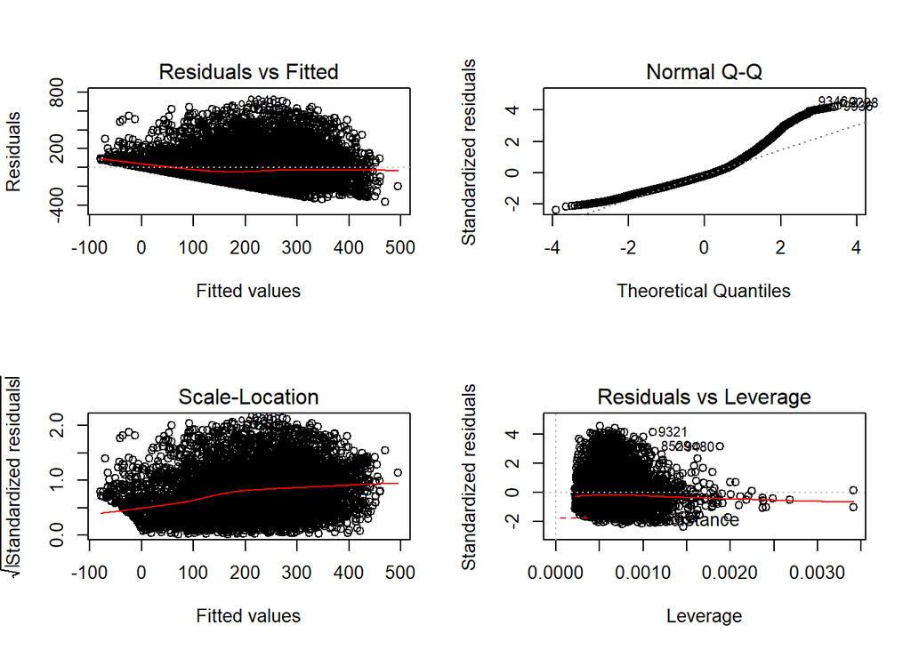

```r
par(mfrow = c(2,2))
plot(lm.fit)
```

```r
data_bikeshare_lm2 <- data_bikeshare_lm[-c(9321,8529,9480),]

lm.fit2 <- lm(count~.-atemp,data = data_bikeshare_lm2)

summary(lm.fit2)
```

```
##
## Call:
## lm(formula = count ~ . - atemp, data = data_bikeshare_lm2)
##
## Residuals:
##     Min      1Q  Median      3Q     Max
## -365.65 -101.60  -30.97   64.65  705.98
##
## Coefficients:
##              Estimate Std. Error t value Pr(>|t|)
## (Intercept) 128.01911    8.19600  15.620  < 2e-16 ***
## season3     -37.18547    4.61557  -8.057 8.67e-16 ***
## season4      66.69513    3.67328  18.157  < 2e-16 ***
## weather2     15.35706    3.45857   4.440 9.07e-06 ***
## temp         11.04389    0.24819  44.498  < 2e-16 ***
## humidity     -2.85468    0.08442 -33.817  < 2e-16 ***
## windspeed     0.40875    0.19199   2.129   0.0333 *
## ---
## Signif. codes:  0 '***' 0.001 '**' 0.01 '*' 0.05 '.' 0.1 ' ' 1
##
## Residual standard error: 153.9 on 10876 degrees of freedom
## Multiple R-squared:  0.2761, Adjusted R-squared:  0.2757
## F-statistic: 691.2 on 6 and 10876 DF,  p-value: < 2.2e-16
```

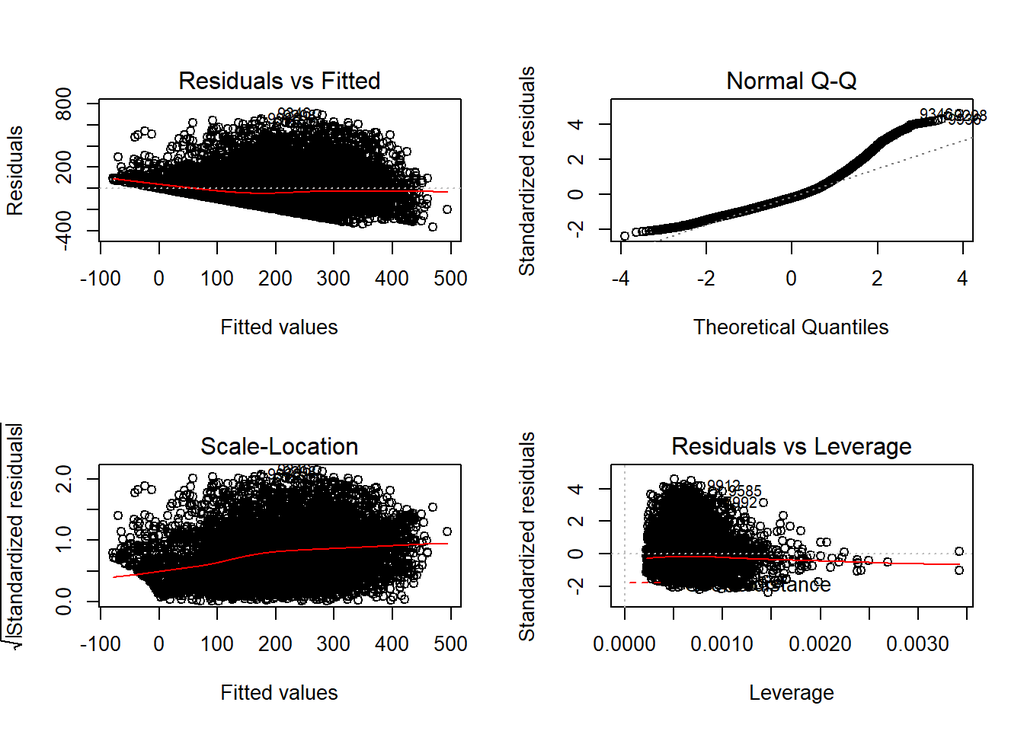

```r
par(mfrow = c(2,2))
plot(lm.fit2)
```

Deleted 9912,9585,7992,9346,9936,9298

```r
data_bikeshare_lm3 <- data_bikeshare_lm2[-c(9912,9585,7992,9346,9936,9298),]

lm.fit3 <- lm(count~.-atemp,data = data_bikeshare_lm3)

summary(lm.fit3)
```

```
##
## Call:
## lm(formula = count ~ . - atemp, data = data_bikeshare_lm3)
##
## Residuals:
##     Min      1Q  Median      3Q     Max
## -365.50 -101.48  -30.99   64.40  706.24
##
## Coefficients:
##              Estimate Std. Error t value Pr(>|t|)
## (Intercept) 128.38281    8.19376  15.668  < 2e-16 ***
## season3     -37.27201    4.61478  -8.077 7.36e-16 ***
## season4      66.72454    3.67249  18.169  < 2e-16 ***
## weather2     15.30717    3.45788   4.427 9.66e-06 ***
## temp         11.03607    0.24813  44.477  < 2e-16 ***
## humidity     -2.85599    0.08439 -33.844  < 2e-16 ***
## windspeed     0.39272    0.19198   2.046   0.0408 *
## ---
## Signif. codes:  0 '***' 0.001 '**' 0.01 '*' 0.05 '.' 0.1 ' ' 1
##
## Residual standard error: 153.8 on 10870 degrees of freedom
## Multiple R-squared:  0.276,  Adjusted R-squared:  0.2756
## F-statistic: 690.8 on 6 and 10870 DF,  p-value: < 2.2e-16
```

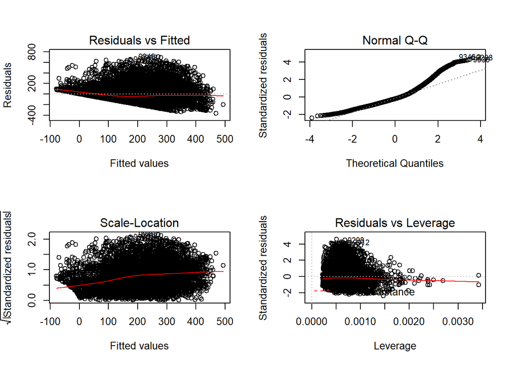

```r
par(mfrow = c(2,2))
plot(lm.fit3)
```

### Final fit and interpretation

Final fit:

```r
library(forecast)
accuracy(data_bikeshare$count,lm.fit3$fitted.values)
```

```
##                  ME    RMSE      MAE      MPE     MAPE
## Test set -0.2342558 161.839 120.9618 14.91394 102.5138
```

### Conclusion

I believe this model can help bike sharing companies develop some business strategies.For example, different rents in different weather and seasons